# LBB: Linear Regression - Graduate Admission

Benarivo

04/04/2020

```r
library(dplyr)
library(GGally)
library(rsample)
library(tidyr)
library(lmtest)
library(car)
library(MLmetrics)
```

# 1 Defining Business Problem

In this project a dataset containing information of graduate admission will be analysed. We will check what predictors affect the chance of admission and how large is their effect.

Linear Regression will be used for this analysis.

First we need to load the data:

```r
admission <- read.csv("Admission_Predict_Ver1.1.csv")
head(admission)
```

```
##   Serial.No. GRE.Score TOEFL.Score University.Rating SOP LOR CGPA Research
## 1          1       337         118                 4 4.5 4.5 9.65        1
## 2          2       324         107                 4 4.0 4.5 8.87        1
## 3          3       316         104                 3 3.0 3.5 8.00        1
## 4          4       322         110                 3 3.5 2.5 8.67        1
## 5          5       314         103                 2 2.0 3.0 8.21        0
## 6          6       330         115                 5 4.5 3.0 9.34        1
##   Chance.of.Admit
## 1            0.92
## 2            0.76
## 3            0.72
## 4            0.80
## 5            0.65
## 6            0.90
```

We need to change ‘Research’ into factor and remove serial as it is a running number and not necessary for our analysis.

```r
admission$Research <- as.factor(admission$Research)
admission <- admission %>%
  select(-Serial.No.)
head(admission)
```

```
##   GRE.Score TOEFL.Score University.Rating SOP LOR CGPA Research Chance.of.Admit
## 1       337         118                 4 4.5 4.5 9.65        1            0.92
## 2       324         107                 4 4.0 4.5 8.87        1            0.76
## 3       316         104                 3 3.0 3.5 8.00        1            0.72
## 4       322         110                 3 3.5 2.5 8.67        1            0.80
## 5       314         103                 2 2.0 3.0 8.21        0            0.65
## 6       330         115                 5 4.5 3.0 9.34        1            0.90
```

# 2 Defining Target Variable

The target is: Chance of being admitted to the Graduate Program ‘Chance.of.Admit’.

# 3 Exploring the Data

## 3.1 Correlation

Now, we will check the correclation between the target and other variables to determine the predictors to be used.

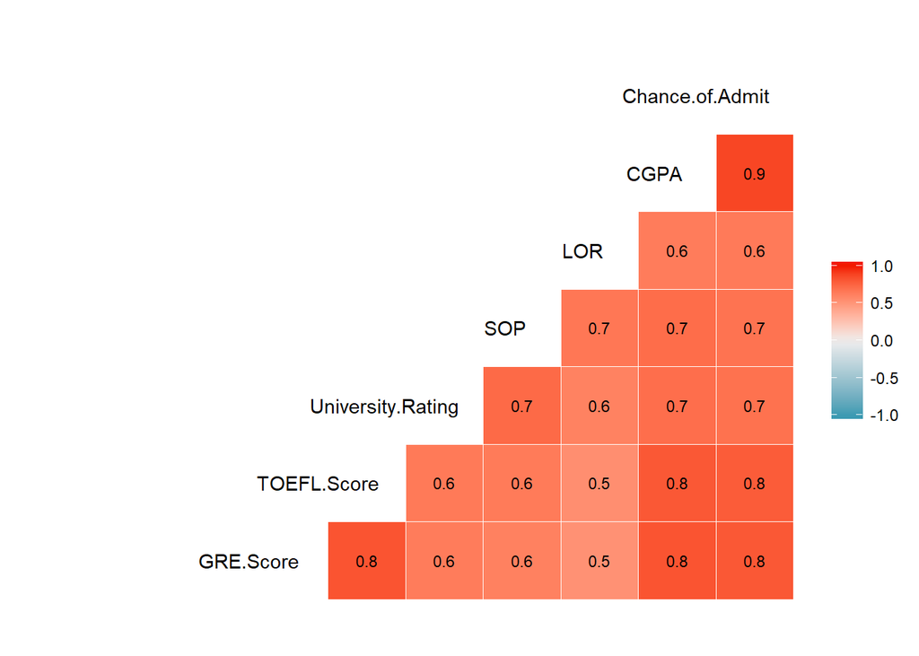

```r
ggcorr(admission, label = T, hjust = 0.9,  label_size = 3, layout.exp = 3)
```

From above graph, we could see that all the variables are highly correlated with the ‘Chance.of.Admit’. Therefore, we will consider all the variables as predictors.

## 3.2 Outliers

The outliers in the predictors then need to be checked.

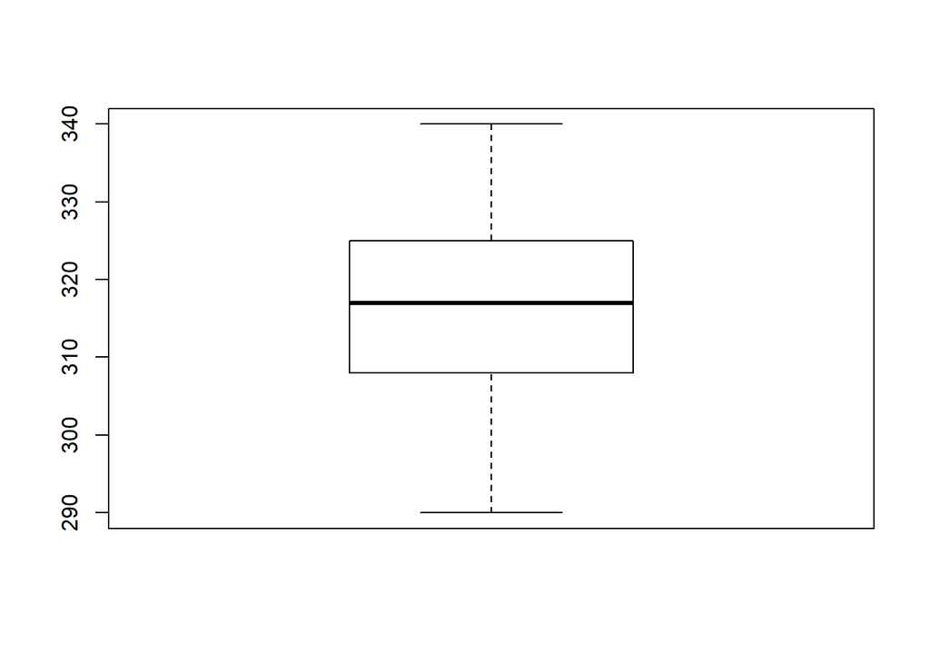

```r
boxplot(admission$GRE.Score)
```

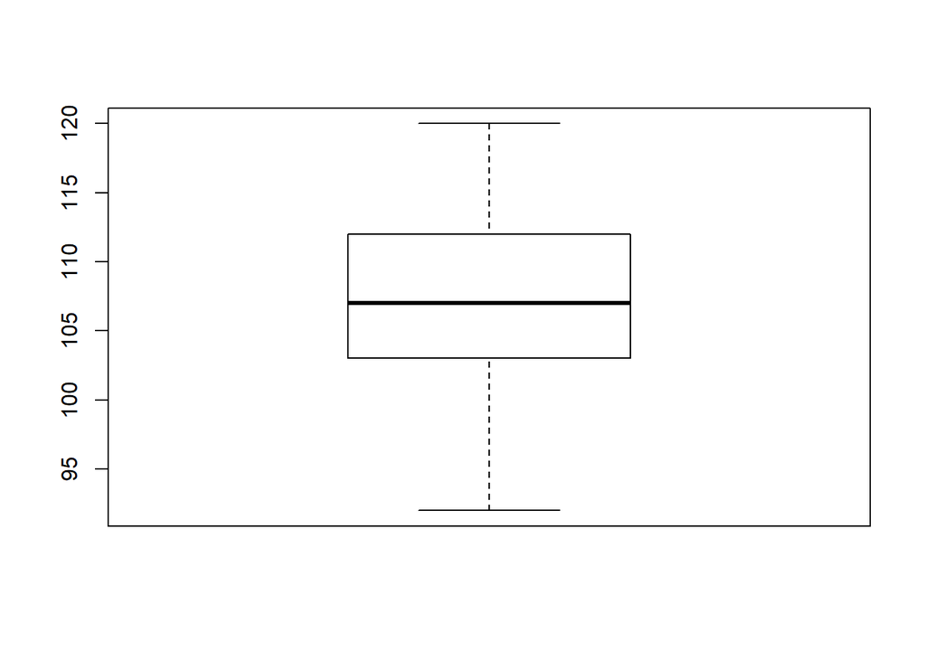

```r
boxplot(admission$TOEFL.Score)
```

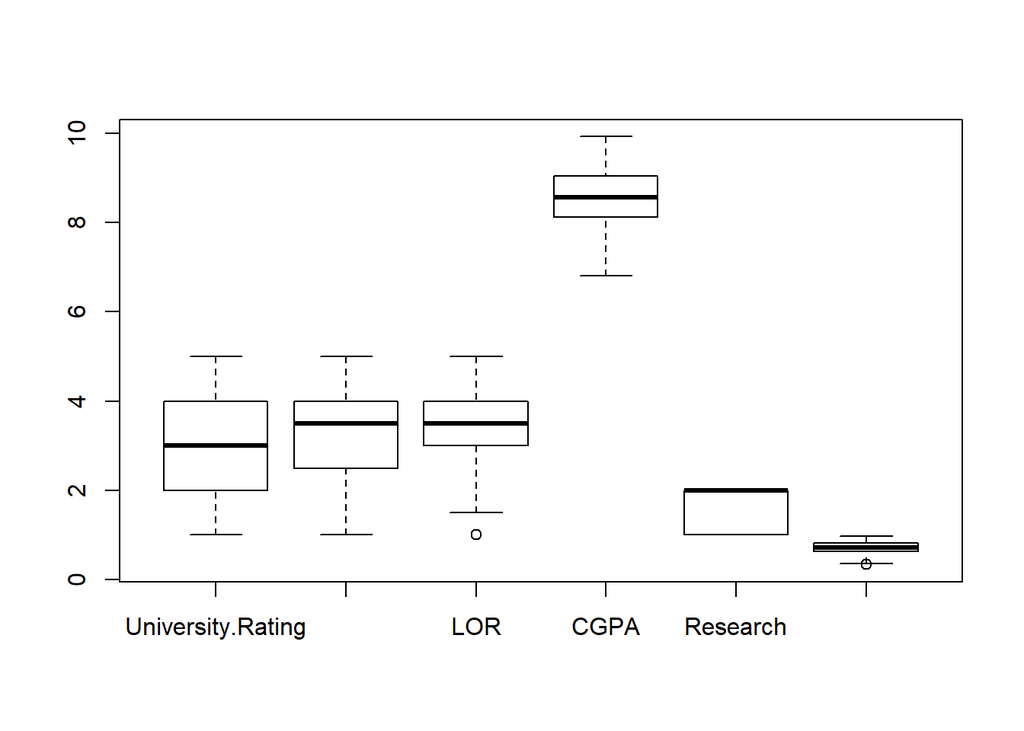

```r
boxplot(admission %>% select(-c(GRE.Score,TOEFL.Score)))
```

From The boxplot above, it could be observed that we have an outlier in the ‘LOR’ and ‘Chance.of.Admit’. However, we will keep the outlier to make sure the data is variative.

# 4 Cross Validation

We need to separate data into train dataset ‘ad_train’ and test dataset ‘ad_test’. 70% of the data will be stored in the train dataset and 30% will be stored in the test dataset.

```r
set.seed(100)
splitted <- initial_split(data = admission, prop = 0.7)
ad_train <- training(splitted)
ad_test <- testing(splitted)
```

# 5 Modeling

To create the models and to choose which predictors that will be used, we will use step wise method:

First, we create a model with all predictors:

```r
model_ad_all <- lm(formula = Chance.of.Admit ~ .,data = ad_train)
summary(model_ad_all)
```

```
##
## Call:
## lm(formula = Chance.of.Admit ~ ., data = ad_train)
##
## Residuals:
##       Min        1Q    Median        3Q       Max
## -0.261210 -0.025295  0.009088  0.034248  0.163378
##
## Coefficients:
##                     Estimate Std. Error t value Pr(>|t|)
## (Intercept)       -1.2201454  0.1242842  -9.817  < 2e-16 ***
## GRE.Score          0.0018473  0.0005884   3.139 0.001841 **
## TOEFL.Score        0.0020934  0.0010807   1.937 0.053557 .
## University.Rating  0.0085692  0.0046353   1.849 0.065363 .
## SOP                0.0018354  0.0054020   0.340 0.734248
## LOR                0.0190077  0.0049933   3.807 0.000167 ***
## CGPA               0.1185401  0.0117661  10.075  < 2e-16 ***
## Research1          0.0252738  0.0081601   3.097 0.002115 **
## ---
## Signif. codes:  0 '***' 0.001 '**' 0.01 '*' 0.05 '.' 0.1 ' ' 1
##
## Residual standard error: 0.06137 on 342 degrees of freedom
## Multiple R-squared:  0.8198, Adjusted R-squared:  0.8161
## F-statistic: 222.2 on 7 and 342 DF,  p-value: < 2.2e-16
```

```r
model_ad_none <- lm(formula = Chance.of.Admit ~ .,data = ad_train)
summary(model_ad_none)
```

```
##
## Call:
## lm(formula = Chance.of.Admit ~ ., data = ad_train)
##
## Residuals:
##       Min        1Q    Median        3Q       Max
## -0.261210 -0.025295  0.009088  0.034248  0.163378
##
## Coefficients:
##                     Estimate Std. Error t value Pr(>|t|)
## (Intercept)       -1.2201454  0.1242842  -9.817  < 2e-16 ***
## GRE.Score          0.0018473  0.0005884   3.139 0.001841 **
## TOEFL.Score        0.0020934  0.0010807   1.937 0.053557 .
## University.Rating  0.0085692  0.0046353   1.849 0.065363 .
## SOP                0.0018354  0.0054020   0.340 0.734248
## LOR                0.0190077  0.0049933   3.807 0.000167 ***
## CGPA               0.1185401  0.0117661  10.075  < 2e-16 ***
## Research1          0.0252738  0.0081601   3.097 0.002115 **
## ---
## Signif. codes:  0 '***' 0.001 '**' 0.01 '*' 0.05 '.' 0.1 ' ' 1
##
## Residual standard error: 0.06137 on 342 degrees of freedom
## Multiple R-squared:  0.8198, Adjusted R-squared:  0.8161
## F-statistic: 222.2 on 7 and 342 DF,  p-value: < 2.2e-16
```

## 5.1 Backward Step-Wise Method

Now, a model with step-wise backward will be created:

```r
step(object = model_ad_all,direction = "backward", trace = 0)
```

```
##
## Call:
## lm(formula = Chance.of.Admit ~ GRE.Score + TOEFL.Score + University.Rating +
##     LOR + CGPA + Research, data = ad_train)
##
## Coefficients:
##       (Intercept)          GRE.Score        TOEFL.Score  University.Rating
##         -1.225246           0.001843           0.002124           0.009194
##               LOR               CGPA          Research1
##          0.019477           0.119205           0.025290
```

```r
model_ad_back <- lm(formula = Chance.of.Admit ~ GRE.Score + TOEFL.Score + University.Rating +
    LOR + CGPA + Research, data = ad_train)
summary(model_ad_back)
```

```
##
## Call:
## lm(formula = Chance.of.Admit ~ GRE.Score + TOEFL.Score + University.Rating +
##     LOR + CGPA + Research, data = ad_train)
##
## Residuals:
##       Min        1Q    Median        3Q       Max
## -0.260705 -0.025379  0.008761  0.034682  0.162588
##
## Coefficients:
##                     Estimate Std. Error t value Pr(>|t|)
## (Intercept)       -1.2252463  0.1232148  -9.944  < 2e-16 ***
## GRE.Score          0.0018434  0.0005876   3.137  0.00185 **
## TOEFL.Score        0.0021237  0.0010756   1.974  0.04914 *
## University.Rating  0.0091939  0.0042495   2.164  0.03119 *
## LOR                0.0194771  0.0047922   4.064 5.98e-05 ***
## CGPA               0.1192052  0.0115871  10.288  < 2e-16 ***
## Research1          0.0252901  0.0081494   3.103  0.00207 **
## ---
## Signif. codes:  0 '***' 0.001 '**' 0.01 '*' 0.05 '.' 0.1 ' ' 1
##
## Residual standard error: 0.06129 on 343 degrees of freedom
## Multiple R-squared:  0.8197, Adjusted R-squared:  0.8165
## F-statistic: 259.9 on 6 and 343 DF,  p-value: < 2.2e-16
```

Based on the step-wise backward method, we do not need the ‘SOP’ data.

## 5.2 Forward Step-Wise Method

Now, let’s create a model using step-wise forward method:

```r
step(object = model_ad_none,scope = list(lower = model_ad_none, upper =model_ad_all),direction = "forward", trace = 0)
```

```
##
## Call:
## lm(formula = Chance.of.Admit ~ GRE.Score + TOEFL.Score + University.Rating +
##     SOP + LOR + CGPA + Research, data = ad_train)
##
## Coefficients:
##       (Intercept)          GRE.Score        TOEFL.Score  University.Rating
##         -1.220145           0.001847           0.002093           0.008569
##               SOP                LOR               CGPA          Research1
##          0.001835           0.019008           0.118540           0.025274
```

```r
model_ad_forward <-  lm(formula = Chance.of.Admit ~ GRE.Score + TOEFL.Score + University.Rating +
    SOP + LOR + CGPA + Research, data = ad_train)
summary(model_ad_forward)
```

```
##
## Call:
## lm(formula = Chance.of.Admit ~ GRE.Score + TOEFL.Score + University.Rating +
##     SOP + LOR + CGPA + Research, data = ad_train)
##
## Residuals:
##       Min        1Q    Median        3Q       Max
## -0.261210 -0.025295  0.009088  0.034248  0.163378
##
## Coefficients:
##                     Estimate Std. Error t value Pr(>|t|)
## (Intercept)       -1.2201454  0.1242842  -9.817  < 2e-16 ***
## GRE.Score          0.0018473  0.0005884   3.139 0.001841 **
## TOEFL.Score        0.0020934  0.0010807   1.937 0.053557 .
## University.Rating  0.0085692  0.0046353   1.849 0.065363 .
## SOP                0.0018354  0.0054020   0.340 0.734248
## LOR                0.0190077  0.0049933   3.807 0.000167 ***
## CGPA               0.1185401  0.0117661  10.075  < 2e-16 ***
## Research1          0.0252738  0.0081601   3.097 0.002115 **
## ---
## Signif. codes:  0 '***' 0.001 '**' 0.01 '*' 0.05 '.' 0.1 ' ' 1
##
## Residual standard error: 0.06137 on 342 degrees of freedom
## Multiple R-squared:  0.8198, Adjusted R-squared:  0.8161
## F-statistic: 222.2 on 7 and 342 DF,  p-value: < 2.2e-16
```

By using a forward step-wise method, all the predictors are needed.

## 5.3 Combination of Forward and Backward Step-Wise Method

We will now try the combination of forward and backward step-wise:

```r
step(object = model_ad_all,scope = list(lower = model_ad_none, upper =model_ad_all),direction = "both", trace = 0)
```

```
##
## Call:
## lm(formula = Chance.of.Admit ~ GRE.Score + TOEFL.Score + University.Rating +
##     SOP + LOR + CGPA + Research, data = ad_train)
##
## Coefficients:
##       (Intercept)          GRE.Score        TOEFL.Score  University.Rating
##         -1.220145           0.001847           0.002093           0.008569
##               SOP                LOR               CGPA          Research1
##          0.001835           0.019008           0.118540           0.025274
```

```r
model_ad_both <- lm(formula = Chance.of.Admit ~ GRE.Score + TOEFL.Score + University.Rating +
    SOP + LOR + CGPA + Research, data = ad_train)
summary(model_ad_both)
```

```
##
## Call:
## lm(formula = Chance.of.Admit ~ GRE.Score + TOEFL.Score + University.Rating +
##     SOP + LOR + CGPA + Research, data = ad_train)
##
## Residuals:
##       Min        1Q    Median        3Q       Max
## -0.261210 -0.025295  0.009088  0.034248  0.163378
##
## Coefficients:
##                     Estimate Std. Error t value Pr(>|t|)
## (Intercept)       -1.2201454  0.1242842  -9.817  < 2e-16 ***
## GRE.Score          0.0018473  0.0005884   3.139 0.001841 **
## TOEFL.Score        0.0020934  0.0010807   1.937 0.053557 .
## University.Rating  0.0085692  0.0046353   1.849 0.065363 .
## SOP                0.0018354  0.0054020   0.340 0.734248
## LOR                0.0190077  0.0049933   3.807 0.000167 ***
## CGPA               0.1185401  0.0117661  10.075  < 2e-16 ***
## Research1          0.0252738  0.0081601   3.097 0.002115 **
## ---
## Signif. codes:  0 '***' 0.001 '**' 0.01 '*' 0.05 '.' 0.1 ' ' 1
##
## Residual standard error: 0.06137 on 342 degrees of freedom
## Multiple R-squared:  0.8198, Adjusted R-squared:  0.8161
## F-statistic: 222.2 on 7 and 342 DF,  p-value: < 2.2e-16
```

By using both forward and backward step-wise method, we need all predictors for the model.

## 5.4 Selecting the Model

To compare all the models, the adjusted r-squared for each model needs to be calculated and compared:

```r
summary(model_ad_back)$adj.r.squared
```

```
## [1] 0.8165432
```

```r
summary(model_ad_forward)$adj.r.squared
```

```
## [1] 0.8160688
```

```r
summary(model_ad_both)$adj.r.squared
```

```
## [1] 0.8160688
```

# 6 Assumption Check

In this chapter, we will check our assumptions for normality, heteroscedacity and multicolinearity.

## 6.1 Normality

For the normality assumption check, we will checkt the distribution of the model’s residual using Shapiro-Wilk Test ‘shapiro.test()’. If the p-value > alpha (0.05), therefore H0 is not rejected.

H0: residuals of the model are normaly distributed

H1: residuals of the model are not normaly distributed

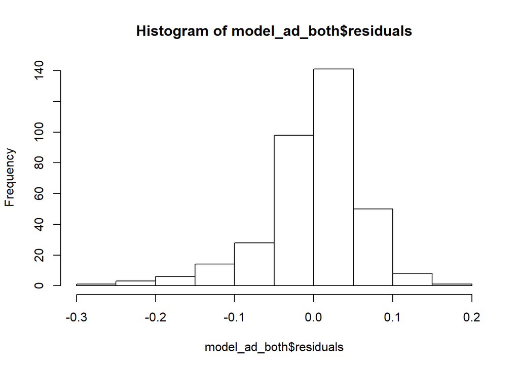

```r
hist(model_ad_both$residuals)
```

```r
shapiro.test(x = model_ad_both$residuals)
```

```
##
##  Shapiro-Wilk normality test
##
## data:  model_ad_both$residuals
## W = 0.93288, p-value = 1.861e-11
```

The p-value of ‘model_ad_both’’s residual is 1.861e-11 which is under 0.05, Therefore we reject H0 and accepts H1.

H1: residuals of the model are not normaly distributed.

One of the solution to have a more normaly distributed residuals is to collect more data to create the model.

## 6.2 Heteroscedasticity

For Heteroscedasticity assumption check,we are checking if the residuals of our model is to check if the residuals are spreading without any pattern. On other hand, it is to check if heteroscedasticity is happening or not.

For this assumption check, Breusch-Pagan hypothesis test ‘bptest’ is used: If the p-value > alpha (0.05), therefore H0 is not rejected.

H0: The residuals are spreading constantly (Homoscedasticity)

H1: The residuals are not spreading constantly/making a pattern (Heteroscedasticity)

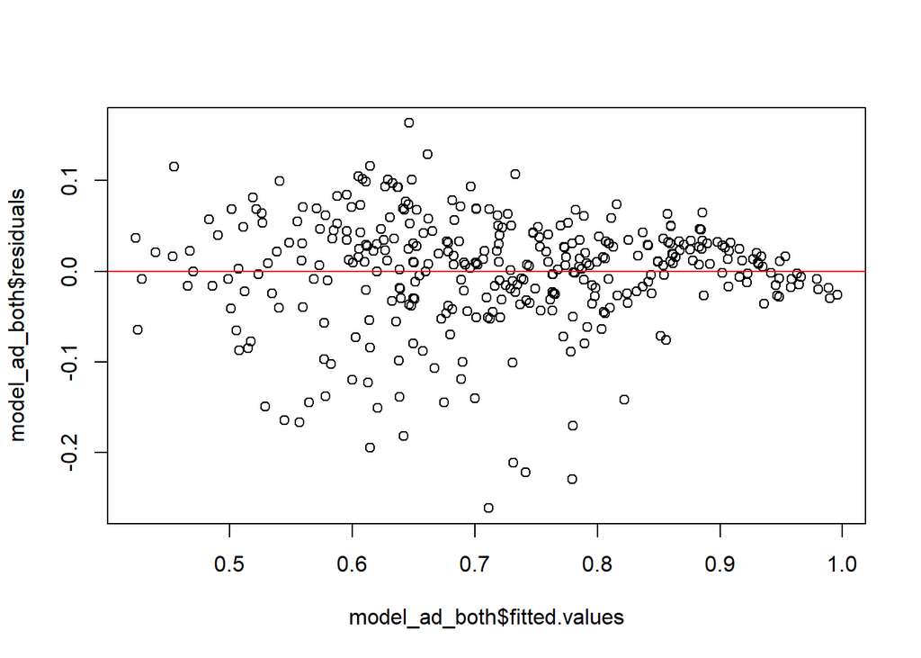

```r
plot(model_ad_both$fitted.values, model_ad_both$residuals)
abline(h = 0, col = "red")
```

```r
bptest(model_ad_both)
```

```
##
##  studentized Breusch-Pagan test
##
## data:  model_ad_both
## BP = 20.638, df = 7, p-value = 0.004345
```

The p-value from ‘bptest()’ is 0.0043, which is under 0.05, therefore H0 is rejected and H1 is accepted.

H1: The residuals are not spreading constantly/making a pattern (Heteroscedasticity)

This could be fixed by having more variance in the training dataset.

## 6.3 Multincolinearity

For multicolinearity assumption check, we want to know whether the predictors are independent against each other. This can be seen by the VIF(Variance Inflation Factor) value of each predictors.

```r
vif(model_ad_both)
```

```
##         GRE.Score       TOEFL.Score University.Rating               SOP
##          4.170321          4.085161          2.739487          2.833074
##               LOR              CGPA          Research
##          2.057611          4.736459          1.522753
```

The VIF values are under 10, therefore, there are no multicolinearities between the predictors.

# 7 Predicting and Calculating Error

Now, we will predict the value of the chance of admission using our model ‘model_ad_both’ with data for the predictors from the test dataset ‘ad_test’.

```r
ad_pred_test <- predict(object = model_ad_both,newdata = ad_test)
ad_pred_test
```

```
##         4         7        12        16        26        31        37        39
## 0.7376172 0.7055566 0.8355675 0.6432384 0.9590335 0.6022122 0.6503366 0.4928697
##        42        44        47        48        55        68        71        72
## 0.6499482 0.8353582 0.8991773 0.9321692 0.6510115 0.7271357 0.9552316 0.9642853
##        87        88        91        93        95        98       100       112
## 0.6822469 0.6515308 0.6538095 0.5688748 0.5317394 0.8389823 0.8000673 0.7728604
##       116       118       121       131       133       137       143       146
## 0.7993562 0.5030528 0.9491969 0.9626747 0.7009686 0.6844027 0.8930493 0.7253243
##       147       148       149       151       154       156       158       167
## 0.6636698 0.8141236 0.9440261 0.8962470 0.7426481 0.7027341 0.6158447 0.6658664
##       170       171       182       183       185       191       194       196
## 0.5863027 0.6342269 0.6346198 0.5647963 0.6695041 0.8489752 0.9486637 0.6953676
##       201       202       206       211       216       218       219       220
## 0.7059854 0.7007274 0.5176280 0.8241191 0.9046553 0.8262034 0.8035330 0.6706830
##       221       222       223       230       233       245       247       250
## 0.7199766 0.7167318 0.7754590 0.8008642 0.6487775 0.6963525 0.7159952 0.7853413
##       251       254       255       258       261       268       272       280
## 0.7085907 0.9402442 0.8292188 0.7652587 0.8360945 0.6753788 0.5227874 0.6884823
##       281       282       283       288       291       293       296       297
## 0.7273408 0.8194715 0.7449211 0.8561936 0.5523557 0.5467311 0.6608323 0.7029036
##       298       299       301       306       307       311       314       316
## 0.8206733 0.8681876 0.5901288 0.7680945 0.8103621 0.7477502 0.5874403 0.6018964
##       324       326       328       331       332       334       336       337
## 0.5947857 0.8417920 0.5277005 0.7614522 0.6226424 0.7305684 0.8449124 0.7201086
##       341       347       351       353       358       359       363       366
## 0.6965570 0.5080383 0.6946219 0.6187965 0.6042413 0.5450935 0.9105161 0.8399474
##       367       371       377       380       387       390       391       393
## 0.7202596 0.6141455 0.4699560 0.6563504 0.5809970 0.7309832 0.6185236 0.8310307
##       396       398       406       407       408       410       411       413
## 0.8041793 0.9067546 0.5154202 0.6535641 0.6136761 0.5496401 0.5231191 0.6096753
##       420       425       431       435       436       437       440       441
## 0.6209010 0.9107546 0.6606506 0.6231087 0.5786141 0.5524545 0.6557741 0.5346518
##       445       447       450       452       454       456       458       459
## 0.8819205 0.9409822 0.7731158 0.8647651 0.7547665 0.5298564 0.4701464 0.6730627
##       464       466       469       470       471       472       473       477
## 0.5862986 0.6486979 0.8213641 0.8399591 0.8516144 0.6343749 0.9029336 0.5899958
##       478       481       486       492       495       500
## 0.6188426 0.7878381 0.6679416 0.5678490 0.6383791 0.8201397
```

After getting the data protection, we calculate the MSE (Mean Squared Error) and the RMSE (Root Mean Squared Error)

```r
MSE(y_pred = ad_pred_test,y_true = ad_test$Chance.of.Admit)
```

```
## [1] 0.003290572
```

```r
RMSE(y_pred = ad_pred_test,y_true = ad_test$Chance.of.Admit)
```

```
## [1] 0.0573635
```

The MSE of our prediction is: 0.0033 The RMSE of our prediction is: 0.057

# 8 Conclusion

The conclusion of this project is that all the predictors are used, selected using the combination of backward and forward step-wise method:

Below is the summary of the model.

```r
summary(model_ad_both)
```

```
##
## Call:
## lm(formula = Chance.of.Admit ~ GRE.Score + TOEFL.Score + University.Rating +
##     SOP + LOR + CGPA + Research, data = ad_train)
##
## Residuals:
##       Min        1Q    Median        3Q       Max
## -0.261210 -0.025295  0.009088  0.034248  0.163378
##
## Coefficients:
##                     Estimate Std. Error t value Pr(>|t|)
## (Intercept)       -1.2201454  0.1242842  -9.817  < 2e-16 ***
## GRE.Score          0.0018473  0.0005884   3.139 0.001841 **
## TOEFL.Score        0.0020934  0.0010807   1.937 0.053557 .
## University.Rating  0.0085692  0.0046353   1.849 0.065363 .
## SOP                0.0018354  0.0054020   0.340 0.734248
## LOR                0.0190077  0.0049933   3.807 0.000167 ***
## CGPA               0.1185401  0.0117661  10.075  < 2e-16 ***
## Research1          0.0252738  0.0081601   3.097 0.002115 **
## ---
## Signif. codes:  0 '***' 0.001 '**' 0.01 '*' 0.05 '.' 0.1 ' ' 1
##
## Residual standard error: 0.06137 on 342 degrees of freedom
## Multiple R-squared:  0.8198, Adjusted R-squared:  0.8161
## F-statistic: 222.2 on 7 and 342 DF,  p-value: < 2.2e-16
```

The MSE of our prediction is: 0.0033 The RMSE of our prediction is: 0.057

The model does not pass the normality and heteroscedacity assumption check, in order to pass those assumption checks, more variance in our data may be needed.